# Section 12: Clustering

Pablo Arés Gastesi

2026-07-07

# 1 Introduction: supervised vs. unsupervised learning

Every method in this course so far has been **supervised**: our data came with a known “result” — a number to predict (regression), or a class label (logistic regression, LDA/QDA, trees, KNN). That known result is what makes validation possible: split the data into training and test sets, fit on the training set, and check predictions against the *known* answers in the test set, using an MSE, a misclassification rate, or a confusion matrix.

**Unsupervised learning** has no such answer key. K-Means (Section 11) was our first example of it: there is no response variable, only predictors, and the goal is to describe structure in the predictors themselves — in that case, by partitioning observations into a fixed number of clusters. **Clustering** is the same kind of problem approached differently: group observations that are “similar” to each other, with no predefined groups to check against. It is a bit like handing someone a pile of photographs and asking them to sort it into similar-looking piles — one person might group by “nature vs. city”, another by “has a person in it or not.” There is no single right answer, and consequently no test set that can tell us whether the algorithm “got it right.”

Clustering is used, among other things, to group similar customers, similar documents (a step in natural language processing pipelines), or similar images. Section 11 covered **K-Means**, which requires the number of clusters $K$ to be fixed in advance. Here we cover the other major family, **hierarchical (agglomerative) clustering**, which does not need $K$ fixed ahead of time and produces a nice visual summary: the **dendrogram**. PCA (Section 13) rounds out the unsupervised methods in this course.

# 2 Measuring similarity

Hierarchical clustering needs two ingredients: a way to measure the distance between individual **points**, and a way to measure the distance between **clusters** of points (once clusters start forming). It assumes all variables are numeric with no missing values.

## 2.1 Distance between points

The two most common choices are the **Euclidean** distance (ordinary straight-line distance) and the **Manhattan** distance (sum of absolute coordinate differences — like walking along a city grid). For two points $p_1 = (x_1, y_1)$ and $p_2 = (x_2, y_2)$:

$$d_{\text{Euclidean}}(p_1, p_2) = \sqrt{(x_1-x_2)^2 + (y_1-y_2)^2}, \qquad
d_{\text{Manhattan}}(p_1, p_2) = |x_1-x_2| + |y_1-y_2|$$

For $p_1 = (0,0)$ and $p_2 = (3,4)$:

```r
p1 <- c(0, 0); p2 <- c(3, 4)
cat("Euclidean distance:", sqrt(sum((p1 - p2)^2)), "\n")
```

```
## Euclidean distance: 5
```

```r
cat("Manhattan distance:", sum(abs(p1 - p2)), "\n")
```

```
## Manhattan distance: 7
```

## 2.2 Distance between clusters: linkage

Once a cluster contains more than one point, “distance to that cluster” needs its own definition — this choice is called the **linkage** method:

- **Complete (maximum) linkage**: the largest distance between any pair of points, one from each cluster.
- **Single (minimum) linkage**: the smallest such distance.
- **Average linkage**: the mean of all pairwise distances between the two clusters.
- **Centroid linkage**: the distance between the two clusters’ centroids (means).

Let’s compute all four by hand for two toy clusters: $C_1 = \{P_1=(0,0), P_2=(2,2)\}$ and $C_2 = \{P_3=(5,0), P_4=(5,5)\}$.

```r
dist_fun <- function(x1, y1, x2, y2) sqrt((x1 - x2)^2 + (y1 - y2)^2)

d13 <- dist_fun(0, 0, 5, 0)
d14 <- dist_fun(0, 0, 5, 5)
d23 <- dist_fun(2, 2, 5, 0)
d24 <- dist_fun(2, 2, 5, 5)

cat("Point-to-point distances:", round(c(d13, d14, d23, d24), 4), "\n\n")
```

```
## Point-to-point distances: 5 7.0711 3.6056 4.2426
```

```r
cat("Complete (max) linkage: ", max(d13, d14, d23, d24), "\n")
```

```
## Complete (max) linkage:  7.071068
```

```r
cat("Single (min) linkage:   ", min(d13, d14, d23, d24), "\n")
```

```
## Single (min) linkage:    3.605551
```

```r
cat("Average linkage:        ", mean(c(d13, d14, d23, d24)), "\n")
```

```
## Average linkage:         4.979815
```

```r
c1_centroid <- c(1, 1)     # mean of P1, P2
c2_centroid <- c(5, 2.5)   # mean of P3, P4
cat("Centroid linkage:       ", dist_fun(c1_centroid[1], c1_centroid[2],
                                        c2_centroid[1], c2_centroid[2]), "\n")
```

```
## Centroid linkage:        4.272002
```

The four linkage rules give four different numbers for “the” distance between the same two clusters — and, as we will see, they can occasionally produce different dendrograms altogether.

# 3 A graphical example

Consider six labelled points:

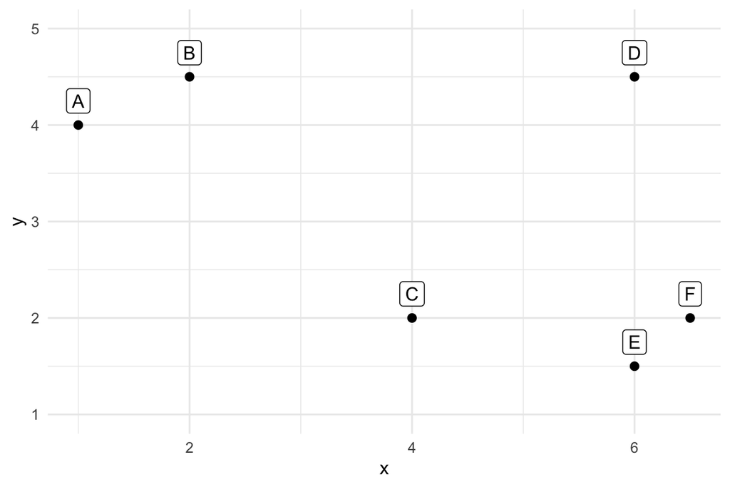

Figure 3.1: Six points to be clustered

```r
datos_ejemplo <- data.frame(x = c(1, 2, 4, 6, 6, 6.5),
                           y = c(4, 4.5, 2, 4.5, 1.5, 2),
                           label = c("A", "B", "C", "D", "E", "F"))

ggplot(datos_ejemplo, aes(x = x, y = y, label = label)) +
  geom_point(size = 2) +
  geom_label(nudge_y = 0.25) +
  expand_limits(x = c(1, 6), y = c(1, 5)) +
  theme_minimal()
```

`dist()` computes every pairwise distance at once:

```r
dist(datos_ejemplo[, 1:2])
```

```
##           1         2         3         4         5
## 2 1.1180340
## 3 3.6055513 3.2015621
## 4 5.0249378 4.0000000 3.2015621
## 5 5.5901699 5.0000000 2.0615528 3.0000000
## 6 5.8523500 5.1478151 2.5000000 2.5495098 0.7071068
```

The smallest distance is between points E and F, so they are merged into the first cluster: $\{A, B, C, D, \{E,F\}\}$. Agglomerative clustering just repeats this — always merging whatever is currently closest — until everything is in one cluster. The **dendrogram** is the visual record of that process:

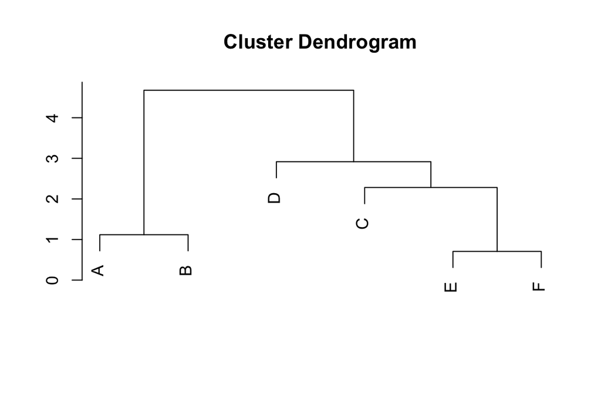

Figure 3.2: Dendrogram, average linkage

```r
plot(hclust(dist(datos_ejemplo[, 1:2]), method = "average"),
    labels = datos_ejemplo$label, xlab = "", sub = "", ylab = "")
```

Reading from the bottom: E and F merge first, then A and B merge separately, then C joins the $\{E,F\}$ cluster, then D joins that enlarged $\{C,E,F\}$ cluster, and finally the two remaining branches ($\{A,B\}$ and $\{C,D,E,F\}$) merge into one. **A note of warning**: the height on the left axis does not measure the distance *between* the final clusters — it only marks *at what point* each merge happened.

A dendrogram is a nested list, and R lets you drill into it directly. For example, the following extracts the first branch, then the first leaf within that branch:

```r
my_cluster <- hclust(dist(datos_ejemplo[, 1:2]), method = "complete")
as.dendrogram(my_cluster)
```

```
## 'dendrogram' with 2 branches and 6 members total, at height 5.85235
```

```r
as.dendrogram(my_cluster)[[1]]
```

```
## 'dendrogram' with 2 branches and 2 members total, at height 1.118034
```

```r
as.dendrogram(my_cluster)[[1]][[1]]
```

```
## 'dendrogram' leaf '1', at height 0
```

## 3.1 Does the linkage method matter?

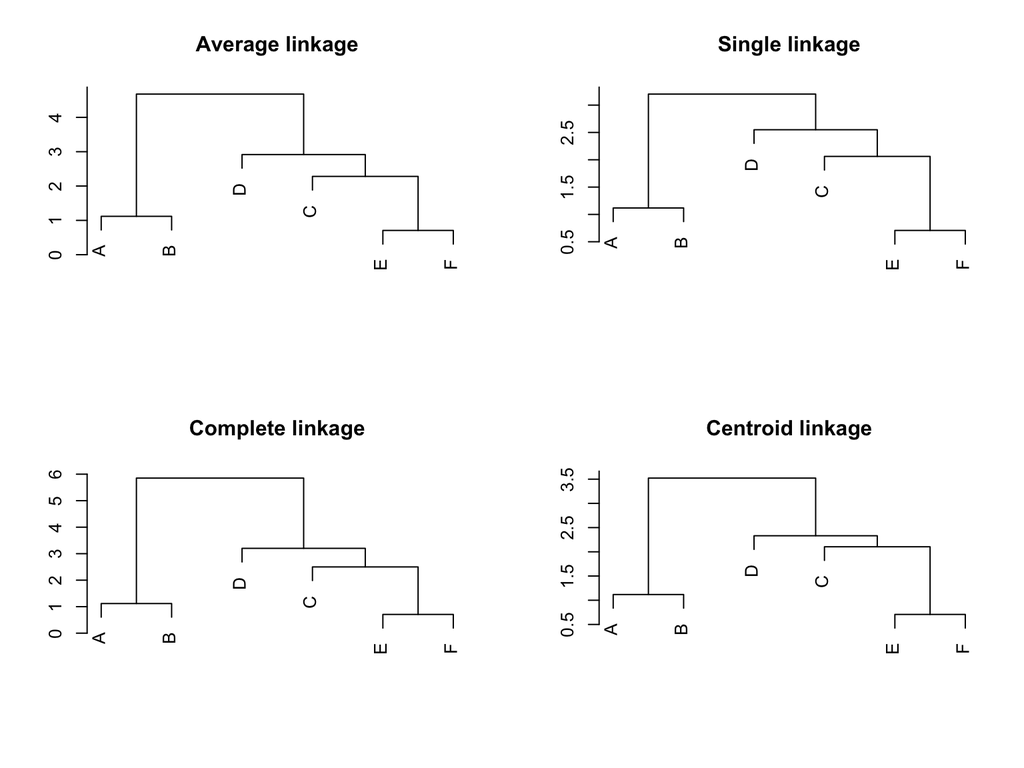

Figure 3.3: The four linkage methods on the same data

```r
par(mfrow = c(2, 2))
for (m in c("average", "single", "complete", "centroid")) {
  plot(hclust(dist(datos_ejemplo[, 1:2]), method = m),
      labels = datos_ejemplo$label, xlab = "", sub = "", ylab = "",
      main = paste(tools::toTitleCase(m), "linkage"))
}
```

```r
par(mfrow = c(1, 1))
```

Here all four methods agree, because the points happen to be well separated into two obvious groups. This will not always be true — linkage choice can and does change the resulting clusters, particularly with noisier or less clearly separated data.

# 4 Scaling

As with every other distance-based method in this course (KNN in Section 10, K-Means in Section 11, PCA in Section 13), variables measured in very different units can dominate the distance calculation purely because of their scale, not because they are more informative. Standardising with `scale()` before clustering removes this artefact.

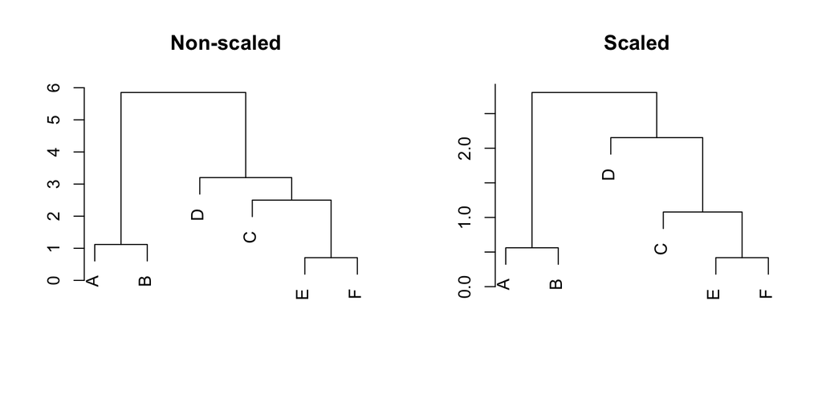

Figure 4.1: Complete linkage before and after scaling

```r
datos_scaled <- data.frame(x = scale(datos_ejemplo$x), y = scale(datos_ejemplo$y),
                           label = datos_ejemplo$label)

par(mfrow = c(1, 2))
plot(hclust(dist(datos_ejemplo[, 1:2]), method = "complete"),
    labels = datos_ejemplo$label, xlab = "", sub = "", ylab = "", main = "Non-scaled")
plot(hclust(dist(datos_scaled[, 1:2]), method = "complete"),
    labels = datos_scaled$label, xlab = "", sub = "", ylab = "", main = "Scaled")
```

```r
par(mfrow = c(1, 1))
```

Here $x$ and $y$ were already on comparable scales, so scaling barely changes anything — but this cannot be assumed in general, and should always be checked (or simply applied by default) before clustering real data with variables in different units, as in the next example.

# 5 Clustering a real dataset: `mtcars`

We cluster cars using three variables: `mpg`, `cyl`, and `disp` (fuel economy, number of cylinders, engine displacement) — all on very different scales.

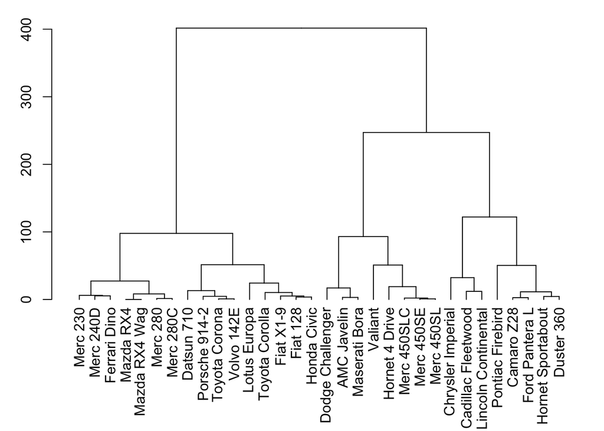

Figure 5.1: mtcars clustered on raw (non-scaled) mpg/cyl/disp

```r
mtcars %>%
  select(mpg, cyl, disp) %>%
  dist() %>%
  hclust() %>%
  as.dendrogram() -> mtcars_dend_raw

par(mar = c(7, 3, 1, 1))
plot(mtcars_dend_raw)
```

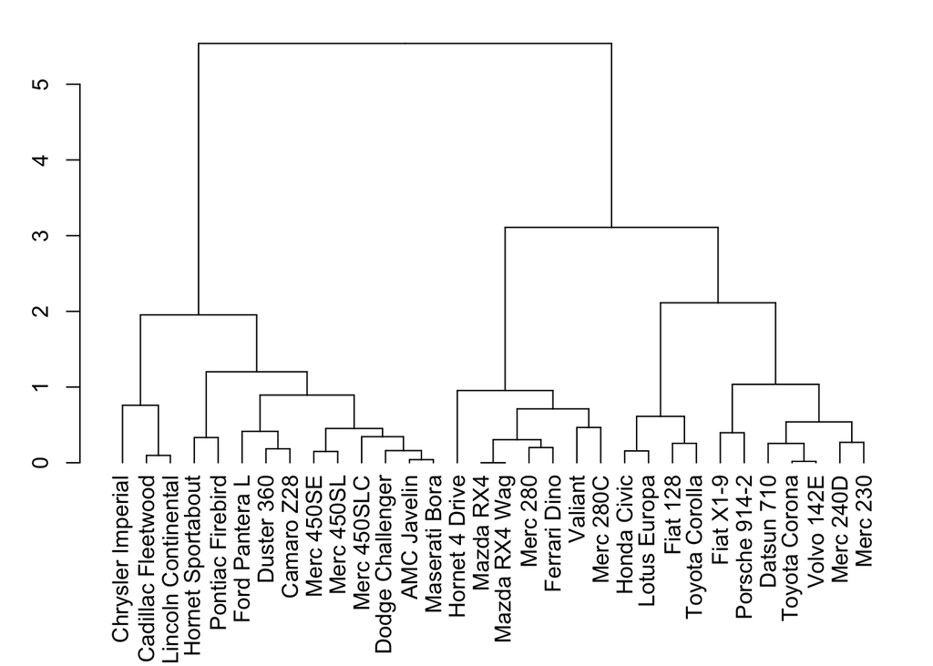

Figure 5.2: mtcars clustered on standardised mpg/cyl/disp

```r
mtcars %>%
  select(mpg, cyl, disp) %>%
  scale() %>%
  dist() %>%
  hclust() %>%
  as.dendrogram() -> mtcars_dend

par(mar = c(7, 3, 1, 1))
plot(mtcars_dend)
```

```r
mtcars %>%
  select(mpg, cyl, disp) %>%
  scale() -> mtcars_scaled

mtcars_scaled[c("Merc 240D", "Merc 230"), ]
```

```
##                 mpg       cyl       disp
## Merc 240D 0.7150178 -1.224858 -0.6779309
## Merc 230  0.4495434 -1.224858 -0.7255351
```

## 5.2 Does the clustering line up with another variable?

It’s natural to ask whether the clusters correspond to some variable we didn’t include — here, transmission type (`am`: automatic vs. manual).

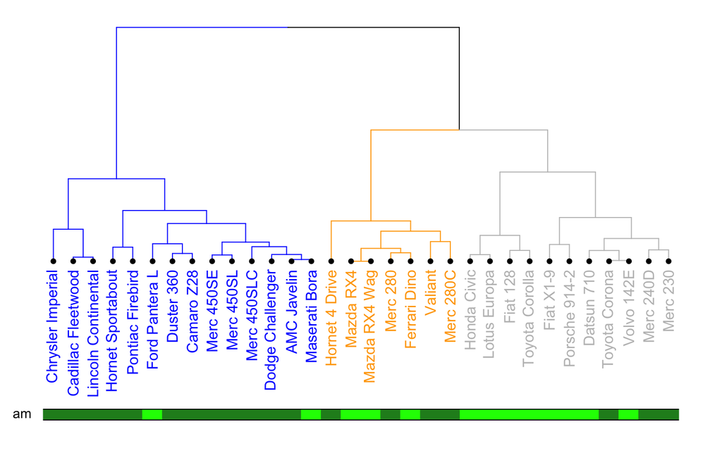

Figure 5.3: mtcars dendrogram (3 clusters) with a transmission-type colour bar

```r
my_colors <- ifelse(mtcars$am == 0, "forestgreen", "green")

par(mar = c(10, 1, 1, 1))
mtcars_dend %>%
  set("labels_col", value = c("blue", "orange", "grey"), k = 3) %>%
  set("branches_k_color", value = c("blue", "orange", "grey"), k = 3) %>%
  set("leaves_pch", 19) %>%
  set("nodes_cex", 0.7) %>%
  plot(axes = FALSE)

colored_bars(colors = my_colors, dend = mtcars_dend, rowLabels = "am")
```

# 6 Clustering variables instead of observations

So far we clustered **observations** (cars). We can just as easily cluster **variables**, to see which ones carry similar information. The natural measure of “closeness” between two variables is correlation: a correlation of $+1$ means one variable is an increasing linear function of the other (as close as two variables can be); $-1$ means a decreasing linear relationship (as far apart as possible). Since distances are usually smallest for the closest objects, we convert correlation to a distance with $1 - \text{correlation}$.

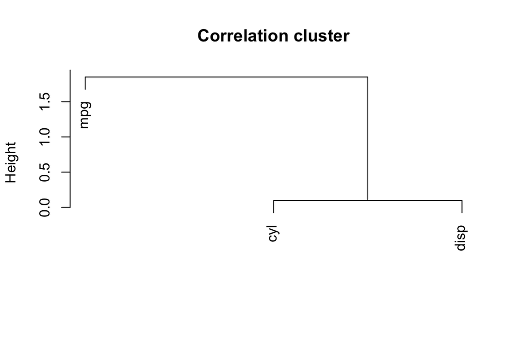

Figure 6.1: Clustering mpg, cyl, disp by correlation distance

```r
my_mtcars <- mtcars %>% select(mpg, cyl, disp)
dd <- as.dist(1 - cor(my_mtcars))
plot(hclust(dd, method = "complete"), main = "Correlation cluster", xlab = "", sub = "")
```

```r
1 - cor(my_mtcars)
```

```
##           mpg        cyl       disp
## mpg  0.000000 1.85216196 1.84755138
## cyl  1.852162 0.00000000 0.09796713
## disp 1.847551 0.09796713 0.00000000
```

`cyl` and `disp` are far closer to each other (correlation distance $\approx 0.10$) than either is to `mpg` (distance $\approx 1.85$) — makes sense, since bigger, more powerful engines (more cylinders, more displacement) go hand in hand, while fuel economy moves in the opposite direction from both. The same idea extends to every numeric variable in the dataset:

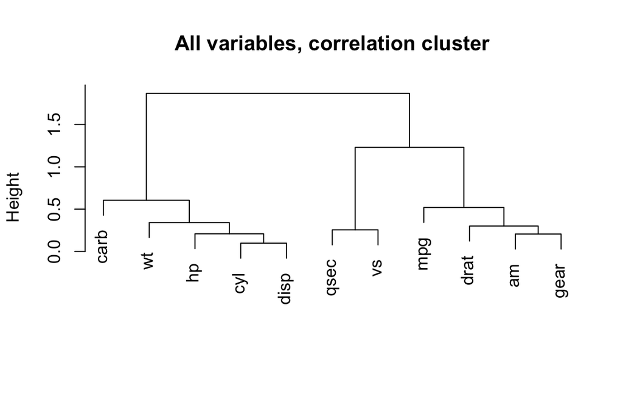

Figure 6.2: Clustering all mtcars variables by correlation distance

```r
dd_all <- as.dist(1 - cor(mtcars))
plot(hclust(dd_all, method = "complete"), main = "All variables, correlation cluster",
    xlab = "", sub = "")
```

# 7 Customising and comparing dendrograms

The `dendextend` package’s `set()` function restyles any part of a dendrogram — branches, nodes, or leaves — and can colour branches by cutting the tree into $k$ groups:

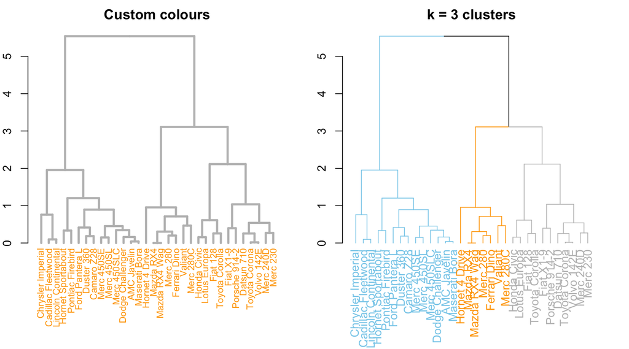

Figure 7.1: Styled branches/labels (left) and k = 3 colouring (right)

```r
par(mfrow = c(1, 2), mar = c(7, 2, 2, 2))

mtcars_dend %>%
  set("branches_col", "grey") %>% set("branches_lwd", 3) %>%
  set("labels_col", "orange") %>% set("labels_cex", 0.8) %>%
  plot(main = "Custom colours")

mtcars_dend %>%
  set("labels_col", value = c("skyblue", "orange", "grey"), k = 3) %>%
  set("branches_k_color", value = c("skyblue", "orange", "grey"), k = 3) %>%
  plot(main = "k = 3 clusters")
```

```r
par(mfrow = c(1, 1))
```

`rect.dendrogram()` draws a box around each of the $k$ clusters directly on the plot, which is often clearer than colour alone:

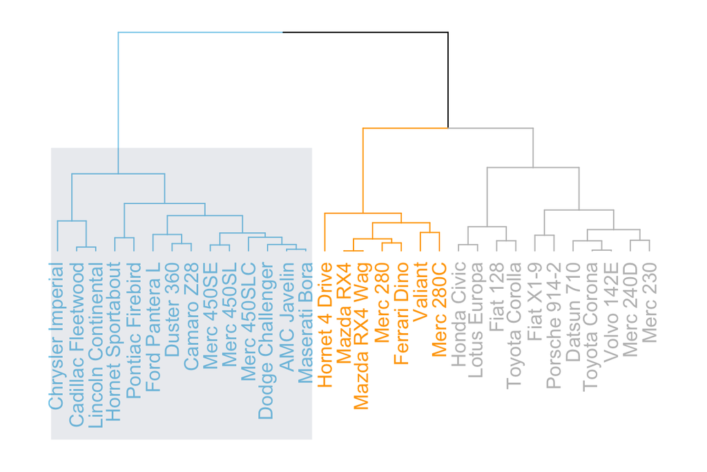

```r
par(mar = c(9, 1, 1, 1))
mtcars_dend %>%
  set("labels_col", value = c("skyblue", "orange", "grey"), k = 3) %>%
  set("branches_k_color", value = c("skyblue", "orange", "grey"), k = 3) %>%
  plot(axes = FALSE)
rect.dendrogram(mtcars_dend, k = 3, lty = 5, lwd = 0, x = 1,
               col = rgb(0.1, 0.2, 0.4, 0.1))
```

## 7.1 Comparing two linkage methods with a tanglegram

Since the choice of linkage can change the result, it’s useful to compare two dendrograms directly. A **tanglegram** places two trees side by side and draws connecting lines between matching leaves — straight, parallel lines mean the two methods agree; crossing lines highlight where they disagree.

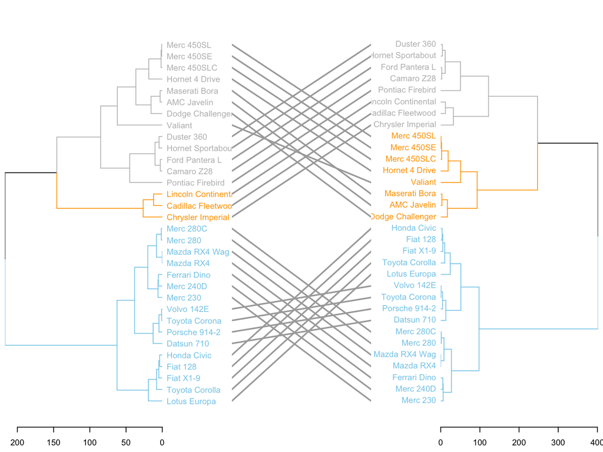

Figure 7.3: Average linkage (left) vs. complete linkage (right), mtcars

```r
mtcars %>% select(mpg, cyl, disp) %>% dist() %>%
  hclust(method = "complete") %>% as.dendrogram() -> mtcars_complete
mtcars %>% select(mpg, cyl, disp) %>% dist() %>%
  hclust(method = "average") %>% as.dendrogram() -> mtcars_average

dl <- dendlist(
  mtcars_average %>%
    set("labels_col", value = c("skyblue", "orange", "grey"), k = 3) %>%
    set("branches_lty", 1) %>%
    set("branches_k_color", value = c("skyblue", "orange", "grey"), k = 3),
  mtcars_complete %>%
    set("labels_col", value = c("skyblue", "orange", "grey"), k = 3) %>%
    set("branches_lty", 1) %>%
    set("branches_k_color", value = c("skyblue", "orange", "grey"), k = 3)
)

tanglegram(dl, common_subtrees_color_lines = FALSE, highlight_distinct_edges = TRUE,
          highlight_branches_lwd = FALSE, margin_inner = 7, lwd = 2)
```

The same approach works for any pair of clusterings on any dataset — e.g. comparing average vs. complete linkage on the (scaled) `USArrests` data — simply build two dendrograms and pass them to `dendlist()`.

## 7.2 Alternative layouts

`ape::as.phylo()` converts a dendrogram into a “phylogenetic tree” object, unlocking circular layouts that can be easier to read with many leaves:

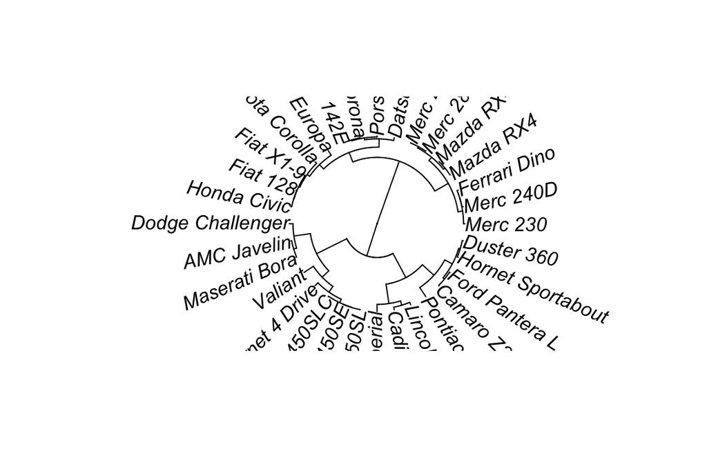

Figure 7.4: Fan layout of the mtcars complete-linkage dendrogram

```r
plot(as.phylo(mtcars_complete), type = "fan")
```

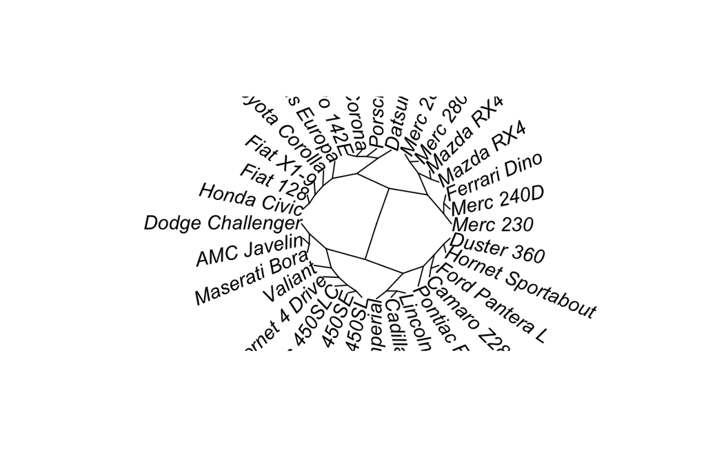

Figure 7.5: Radial layout of the same dendrogram

```r
plot(as.phylo(mtcars_complete), type = "radial")
```

# 8 Summary

- Clustering is **unsupervised**: there is no known answer to validate against, unlike every classification/regression method earlier in the course.
- **Hierarchical (agglomerative) clustering** repeatedly merges whichever two clusters are currently closest, until everything is in a single cluster; the process is visualised as a **dendrogram**.
- Two choices drive the result: the distance between individual points (Euclidean, Manhattan, …) and the **linkage** rule for distance between clusters (single/complete/average/centroid) — these can disagree, so it is worth checking more than one.
- The dendrogram’s vertical axis marks *when* a merge happened, not the distance between the final clusters.
- As with every other distance-based method in this course, **standardise** variables on different scales before clustering observations.
- Clustering **variables** (rather than observations) using $1 - \text{correlation}$ as a distance is a quick way to spot redundant or closely related predictors.

| Concept | Function | Notes |
| --- | --- | --- |
| Pairwise distances | `dist()` | Euclidean by default; `method = "manhattan"` etc. available |
| Hierarchical clustering | `hclust(d, method = ...)` | linkage: `"single"`, `"complete"`, `"average"`, `"centroid"` |
| Convert to dendrogram | `as.dendrogram()` | supports `[[ ]]` indexing to inspect sub-branches |
| Style a dendrogram | `dendextend::set(...)` | colour/style branches, nodes, leaves; cut into k groups |
| Highlight k clusters | `rect.dendrogram(dend, k = ...)` | draws boxes around each cluster |
| Compare two dendrograms | `dendextend::tanglegram(dendlist(d1, d2))` | crossing lines = disagreement |
| Circular layouts | `ape::as.phylo(dend)` + `plot(type = "fan"/"radial")` | easier to read with many leaves |
| Cluster variables | `as.dist(1 - cor(data))` | groups variables that carry similar information |

Key takeaway: hierarchical clustering asks no question about a response variable — it only asks “which observations (or variables) look alike?” — which makes it flexible and exploratory, but also means there is no built-in way to check whether the groups it finds are “correct”: that judgement is left to the analyst and to how well the clusters line up with domain knowledge.